# Replicating Marine Policy Study

John Lynham

03/13/2020

Goal is to replicate this paper:

[figure not shown]

https://www.sciencedirect.com/science/article/pii/S0308597X19300090?dgcid=raven_sd_aip_email

## Remaining steps:

1. Generate CPUE measure and test whether it still holds
2. Use different cutoffs for treatment groups
24. Productivity inside vs. outside

Let’s load the observer dataset

```r
rm(list = ls())
library(foreign)
library(sandwich)
library(lmtest)
library(car)
library(AER)
library(stargazer)
```

```r
library(data.table)
library(ggplot2)
options(max.print=100000)

NOAA.raw <- read.csv(file="/Users/lynham/Documents/CSF MPA Project/cleaned_observer_data_090618.csv", header=TRUE, sep=",")

setnames(NOAA.raw, "set_year", "SET_YEAR")
setnames(NOAA.raw, "set_month", "SET_MONTH")
setnames(NOAA.raw, "set_day", "SET_DAY")
setnames(NOAA.raw, "hawaii", "HAWAII")

NOAA.raw$date_value <- as.Date(NOAA.raw$date,"%m/%d/%y")

NOAA.raw$PRI_dummy <- as.numeric((NOAA.raw$SET_YEAR >= 2014) & (NOAA.raw$SET_MONTH >= 9) & (NOAA.raw$SET_DAY >= 25)| (NOAA.raw$SET_YEAR >= 2014) & (NOAA.raw$SET_MONTH >= 10) | (NOAA.raw$SET_YEAR >= 2015))
NOAA.raw$PMNM_dummy <- as.numeric((NOAA.raw$SET_YEAR >= 2016) & (NOAA.raw$SET_MONTH >= 8) & (NOAA.raw$SET_DAY >= 26)| (NOAA.raw$SET_YEAR >= 2016) & (NOAA.raw$SET_MONTH >= 9) | (NOAA.raw$SET_YEAR >= 2017))

NOAA.raw$WCPFC_2017 <- as.numeric((NOAA.raw$SET_YEAR == 2017) & (NOAA.raw$SET_MONTH == 9) | (NOAA.raw$SET_YEAR == 2017) & (NOAA.raw$SET_MONTH == 10) & (NOAA.raw$SET_DAY <= 9))
NOAA.raw$WCPFC_2016 <- as.numeric((NOAA.raw$SET_YEAR == 2016) & (NOAA.raw$SET_MONTH == 7) & (NOAA.raw$SET_DAY >= 22) | (NOAA.raw$SET_YEAR == 2016) & (NOAA.raw$SET_MONTH == 8) |(NOAA.raw$SET_YEAR == 2016) & (NOAA.raw$SET_MONTH == 9) & (NOAA.raw$SET_DAY <= 8))
NOAA.raw$WCPFC_2015 <- as.numeric((NOAA.raw$SET_YEAR == 2015) & (NOAA.raw$SET_MONTH == 8) & (NOAA.raw$SET_DAY >= 15) | (NOAA.raw$SET_YEAR == 2015) & (NOAA.raw$SET_MONTH == 9) |(NOAA.raw$SET_YEAR == 2015) & (NOAA.raw$SET_MONTH == 10) & (NOAA.raw$SET_DAY <= 8))
NOAA.raw$WCPFC_2010 <- as.numeric((NOAA.raw$SET_YEAR == 2010) & (NOAA.raw$SET_MONTH == 11) & (NOAA.raw$SET_DAY >= 22) | (NOAA.raw$SET_YEAR == 2010) & (NOAA.raw$SET_MONTH == 12))
NOAA.raw$WCPFC_2009 <- as.numeric((NOAA.raw$SET_YEAR == 2009) & (NOAA.raw$SET_MONTH == 12) & (NOAA.raw$SET_DAY >= 27))

NOAA.raw$WCPFC_close <- NOAA.raw$WCPFC_2009 + NOAA.raw$WCPFC_2010 + NOAA.raw$WCPFC_2015 + NOAA.raw$WCPFC_2016 + NOAA.raw$WCPFC_2017
NOAA.raw$WCPFC_2009<-NULL
NOAA.raw$WCPFC_2010<-NULL
NOAA.raw$WCPFC_2015<-NULL
NOAA.raw$WCPFC_2016<-NULL
NOAA.raw$WCPFC_2017<-NULL

NOAA.raw$IATTC_2017 <- as.numeric((NOAA.raw$SET_YEAR == 2017) & (NOAA.raw$SET_MONTH == 9) & (NOAA.raw$SET_DAY >= 8) | (NOAA.raw$SET_YEAR == 2017) & (NOAA.raw$SET_MONTH == 10) | (NOAA.raw$SET_YEAR == 2017) & (NOAA.raw$SET_MONTH == 11) | (NOAA.raw$SET_YEAR == 2017) & (NOAA.raw$SET_MONTH == 12))
NOAA.raw$IATTC_2016 <- as.numeric((NOAA.raw$SET_YEAR == 2016) & (NOAA.raw$SET_MONTH == 7) & (NOAA.raw$SET_DAY >= 25) | (NOAA.raw$SET_YEAR == 2016) & (NOAA.raw$SET_MONTH == 8) | (NOAA.raw$SET_YEAR == 2016) & (NOAA.raw$SET_MONTH == 9) | (NOAA.raw$SET_YEAR == 2016) & (NOAA.raw$SET_MONTH == 10) & (NOAA.raw$SET_DAY < 4))
NOAA.raw$IATTC_2015 <- as.numeric((NOAA.raw$SET_YEAR == 2015) & (NOAA.raw$SET_MONTH == 8) & (NOAA.raw$SET_DAY >= 12) | (NOAA.raw$SET_YEAR == 2015) & (NOAA.raw$SET_MONTH >= 9) )
NOAA.raw$IATTC_2014 <- as.numeric((NOAA.raw$SET_YEAR == 2014) & (NOAA.raw$SET_MONTH == 10) & (NOAA.raw$SET_DAY >= 31) | (NOAA.raw$SET_YEAR == 2014) & (NOAA.raw$SET_MONTH >= 11) )
NOAA.raw$IATTC_2013 <- as.numeric((NOAA.raw$SET_YEAR == 2013) & (NOAA.raw$SET_MONTH == 11) & (NOAA.raw$SET_DAY >= 11) | (NOAA.raw$SET_YEAR == 2013) & (NOAA.raw$SET_MONTH == 12) )

NOAA.raw$IATTC_close <- NOAA.raw$IATTC_2013 + NOAA.raw$IATTC_2014 + NOAA.raw$IATTC_2015 + NOAA.raw$IATTC_2016 + NOAA.raw$IATTC_2017
NOAA.raw$IATTC_2013<-NULL
NOAA.raw$IATTC_2014<-NULL
NOAA.raw$IATTC_2015<-NULL
NOAA.raw$IATTC_2016<-NULL
NOAA.raw$IATTC_2017<-NULL

NOAA.raw$tuna <- NOAA.raw$count_bigeye_tuna + NOAA.raw$count_yellowfin_tuna
NOAA.raw$all_tuna <- NOAA.raw$count_bigeye_tuna + NOAA.raw$count_yellowfin_tuna + NOAA.raw$count_albacore_tuna + NOAA.raw$count_skipjack_tuna + NOAA.raw$count_bluefin_tuna + NOAA.raw$count_unid_tuna
NOAA.raw$tuna.cpue <- (NOAA.raw$tuna/NOAA.raw$num_hks_set)*1000
NOAA.raw$all_tuna.cpue <- (NOAA.raw$all_tuna/NOAA.raw$num_hks_set)*1000
NOAA.raw$sword.cpue <- (NOAA.raw$count_swordfish/NOAA.raw$num_hks_set)*1000

NOAA.raw$deep <- NOAA.raw$sword-1
NOAA.raw <- within(NOAA.raw, deep[sword==0] <- 1)
NOAA.raw$HAWAIITUNA <- NOAA.raw$deep
NOAA.raw <- within(NOAA.raw, HAWAIITUNA[HAWAII==0] <- 0)

newdata <- NOAA.raw[order(NOAA.raw$date_value),]
NOAA.raw <- newdata
rm(newdata)
```

Take 20% of swordfish trips in each year:

```r
#2012
sword.2012 <- subset(NOAA.raw,SET_YEAR==2012 & HAWAII==1 & sword==1) # 1369 obs
sword.2012.trips <- aggregate(SET_MONTH ~ trip_id, sword.2012, mean) # 82 trips
sword.2012.sample <- sword.2012.trips[sample(nrow(sword.2012.trips), 16), ] # 82 * 0.2 = 16.4

#2013
sword.2013 <- subset(NOAA.raw,SET_YEAR==2013 & HAWAII==1 & sword==1) # 960 obs
sword.2013.trips <- aggregate(SET_MONTH ~ trip_id, sword.2013, mean) # 58 trips
sword.2013.sample <- sword.2013.trips[sample(nrow(sword.2013.trips), 12), ] # 58 * 0.2 = 11.6

#2014
sword.2014 <- subset(NOAA.raw,SET_YEAR==2014 & HAWAII==1 & sword==1) # 1336 obs
sword.2014.trips <- aggregate(SET_MONTH ~ trip_id, sword.2014, mean) # 81 trips
sword.2014.sample <- sword.2014.trips[sample(nrow(sword.2014.trips), 16), ] # 81 * 0.2 = 16.2

#2015
sword.2015 <- subset(NOAA.raw,SET_YEAR==2015 & HAWAII==1 & sword==1) # 1156 obs
sword.2015.trips <- aggregate(SET_MONTH ~ trip_id, sword.2015, mean) # 69 trips
sword.2015.sample <- sword.2015.trips[sample(nrow(sword.2015.trips), 14), ] # 69 * 0.2 = 13.8

#2016
sword.2016 <- subset(NOAA.raw,SET_YEAR==2016 & HAWAII==1 & sword==1) # 727 obs
sword.2016.trips <- aggregate(SET_MONTH ~ trip_id, sword.2016, mean) # 45 trips
sword.2016.sample <- sword.2016.trips[sample(nrow(sword.2016.trips), 9), ] # 45 * 0.2 = 9

#2017
sword.2017 <- subset(NOAA.raw,SET_YEAR==2017 & HAWAII==1 & sword==1) # 955 obs
sword.2017.trips <- aggregate(SET_MONTH ~ trip_id, sword.2017, mean) # 70 trips
sword.2017.sample <- sword.2017.trips[sample(nrow(sword.2017.trips), 14), ] # 70 * 0.2 = 14

random.sword.trips <- rbind(sword.2012.sample,sword.2013.sample,sword.2014.sample,sword.2015.sample,sword.2016.sample,sword.2017.sample)
```

Generate a dataset that is just Hawaii tuna trips from observer data and 20% of Hawaii swordfish trips from observer data since 2012:

```r
NOAA.subset <- subset(NOAA.raw,SET_YEAR>=2012 & HAWAII==1 & sword==0| NOAA.raw$trip_id %in% random.sword.trips$trip_id)
```

Calculate % of sets hooks inside and outside PMNM:

Issue: What does this “Among the 44 vessels initially identified as higher effort group, 7 vessels are excluded as they only fished inside the MEA for one year between 2012 and 2016, and had 0%–4% of effort inside the MEA in other years.” mean? Does it mean some vessels exclusively fished inside MEA in one year?

NOTE: Might want to take a random sample of no effort vessels so we have a similar number in both groups

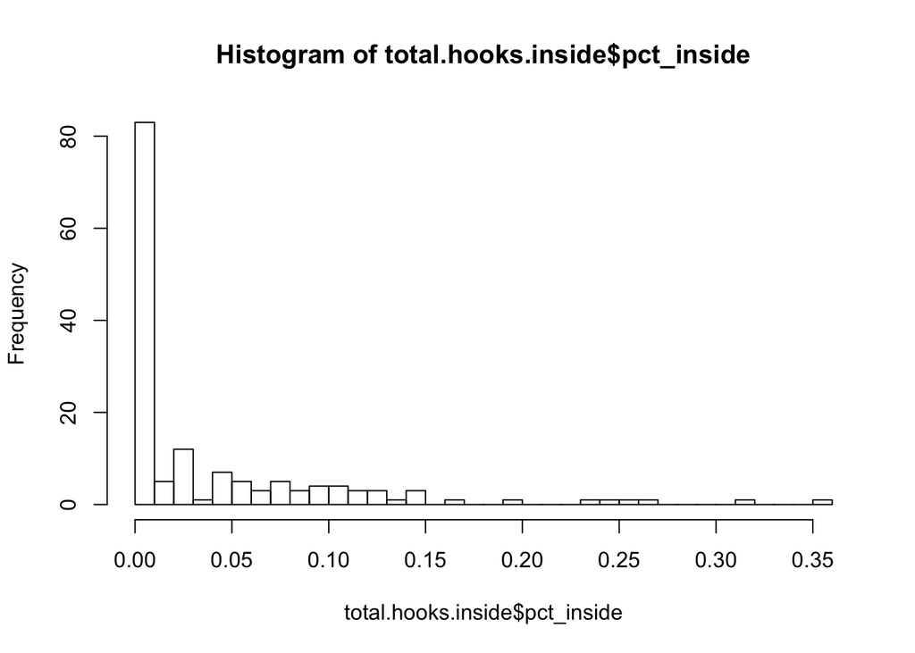

```r
NOAA.subset$inside_PMNM <- as.numeric(as.character(NOAA.subset$inside_PMNM))

NOAA.subset$outside <- 1 - (NOAA.subset$inside_PMNM)

annual.hooks.inside <-aggregate(num_hks_set~SET_YEAR + inside_PMNM + outside + vessel_id,FUN=sum,data=subset(NOAA.subset,PMNM_dummy==0))

annual.hooks.inside$hooks_inside_PMNM <- ifelse(annual.hooks.inside$inside_PMNM==1,annual.hooks.inside$num_hks_set,0)
annual.hooks.inside$hooks_outside_PMNM <- ifelse(annual.hooks.inside$inside_PMNM==0,annual.hooks.inside$num_hks_set,0)

annual.hooks.inside <- aggregate(. ~  vessel_id + SET_YEAR,FUN=sum,data=annual.hooks.inside)
annual.hooks.inside$pct_inside <- annual.hooks.inside$hooks_inside_PMNM/annual.hooks.inside$num_hks_set

total.hooks.inside <-aggregate(. ~  vessel_id,FUN=sum,data=annual.hooks.inside)


total.hooks.inside$pct_inside <- total.hooks.inside$hooks_inside_PMNM/total.hooks.inside$num_hks_set
hist(total.hooks.inside$pct_inside, breaks = 50)
```

```r
total.hooks.inside$high_effort <- ifelse(total.hooks.inside$pct_inside>0.05,1,0)
sum(total.hooks.inside$high_effort) # ~40-41 boats compared to NOAA study estimate of 44 vessels (that is then reduced to 37)
```

```
## [1] 42
```

```r
high.effort.list <- subset(total.hooks.inside, total.hooks.inside$high_effort==1)
NOAA.subset$high_effort <-  ifelse(NOAA.subset$vessel_id %in% high.effort.list$vessel_id,1,0)

# NOTE: we are adjusting the cutoff slightly to get similar number of vessels in each category as the NOAA study
total.hooks.inside$medium_effort <- ifelse(total.hooks.inside$pct_inside>0 & total.hooks.inside$pct_inside<=0.05,1,0) # can change back to >0.01
sum(total.hooks.inside$medium_effort) # ~38 boats compared to NOAA study estimate of 59 to 69 vessels
```

```
## [1] 34
```

```r
medium.effort.list <- subset(total.hooks.inside, total.hooks.inside$medium_effort==1)
NOAA.subset$medium_effort <-  ifelse(NOAA.subset$vessel_id %in% medium.effort.list$vessel_id,1,0)

total.hooks.inside$no_effort <- ifelse(total.hooks.inside$pct_inside==0,1,0)
sum(total.hooks.inside$no_effort) # ~72 boats compared to NOAA study estimate of 38 vessels but 9 are excluded to make it 29
```

```
## [1] 74
```

```r
no.effort.list <- subset(total.hooks.inside, total.hooks.inside$no_effort==1)
# Note need to take a random subset to get this down to about 38 vessels

no.effort.list.sample <- no.effort.list[sample(nrow(no.effort.list), 38), ] #38 or 29?

#NOAA.subset$no_effort <-  ifelse(NOAA.subset$vessel_id %in% no.effort.list$vessel_id,1,0)

NOAA.subset$no_effort <-  ifelse(NOAA.subset$vessel_id %in% no.effort.list.sample$vessel_id,1,0)

NOAA.subset$medium_effort <-  ifelse(NOAA.subset$high_effort==0 & NOAA.subset$no_effort==0,1,0)

# Can we identify vessels to drop that "only fished inside the MEA for one year between 2012 and 2016"?
# there appears to be one vessel FV355346 that fished 100% of observer sets inside PMNM in 2014
# But they also fished inside PMNM a lot in 2012 (52% of hooks) and 2013 (54% of hooks)
# So I don't think we should drop them

# what about identifying vessels that did not fish in 2017 or only fished in 2016?
```

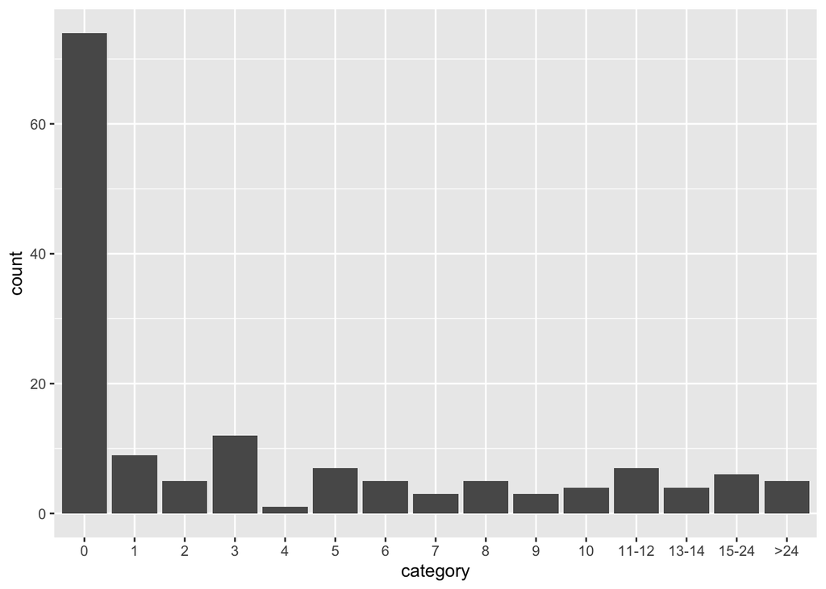

```r
# Replicating the bar chart - create categories for the different cutoffs

# total.hooks.inside$zero_pct <- ifelse(total.hooks.inside$pct_inside==0,1,0)
# total.hooks.inside$one_pct <- ifelse(total.hooks.inside$pct_inside>0 & total.hooks.inside$pct_inside<=0.01,1,0)
# total.hooks.inside$one_pct <- ifelse(total.hooks.inside$pct_inside>0 & total.hooks.inside$pct_inside<=0.01,1,0)
# total.hooks.inside$one_pct <- ifelse(total.hooks.inside$pct_inside>0 & total.hooks.inside$pct_inside<=0.01,1,0)
# total.hooks.inside$one_pct <- ifelse(total.hooks.inside$pct_inside>0 & total.hooks.inside$pct_inside<=0.01,1,0)
# total.hooks.inside$one_pct <- ifelse(total.hooks.inside$pct_inside>0 & total.hooks.inside$pct_inside<=0.01,1,0)
# total.hooks.inside$one_pct <- ifelse(total.hooks.inside$pct_inside>0 & total.hooks.inside$pct_inside<=0.01,1,0)
# total.hooks.inside$one_pct <- ifelse(total.hooks.inside$pct_inside>0 & total.hooks.inside$pct_inside<=0.01,1,0)


total.hooks.inside$category <- ceiling(100*total.hooks.inside$pct_inside)
total.hooks.inside$category <- ifelse(ceiling(100*total.hooks.inside$pct_inside)==11 | ceiling(100*total.hooks.inside$pct_inside)==12,"11-12",total.hooks.inside$category)
total.hooks.inside$category <- ifelse(ceiling(100*total.hooks.inside$pct_inside)==13 | ceiling(100*total.hooks.inside$pct_inside)==14,"13-14",total.hooks.inside$category)
total.hooks.inside$category <- ifelse(ceiling(100*total.hooks.inside$pct_inside)>=15 & ceiling(100*total.hooks.inside$pct_inside)<=24,"15-24",total.hooks.inside$category)
total.hooks.inside$category <- ifelse(ceiling(100*total.hooks.inside$pct_inside)>24,">24",total.hooks.inside$category)

positions <- c("0", "1", "2","3","4","5","6","7","8","9","10","11-12","13-14","15-24",">24")

p <- ggplot(data=total.hooks.inside, mapping = aes(x= category))
p + geom_bar() + scale_x_discrete(limits = positions)
```

This is quite different to the figure in Chan (2020):

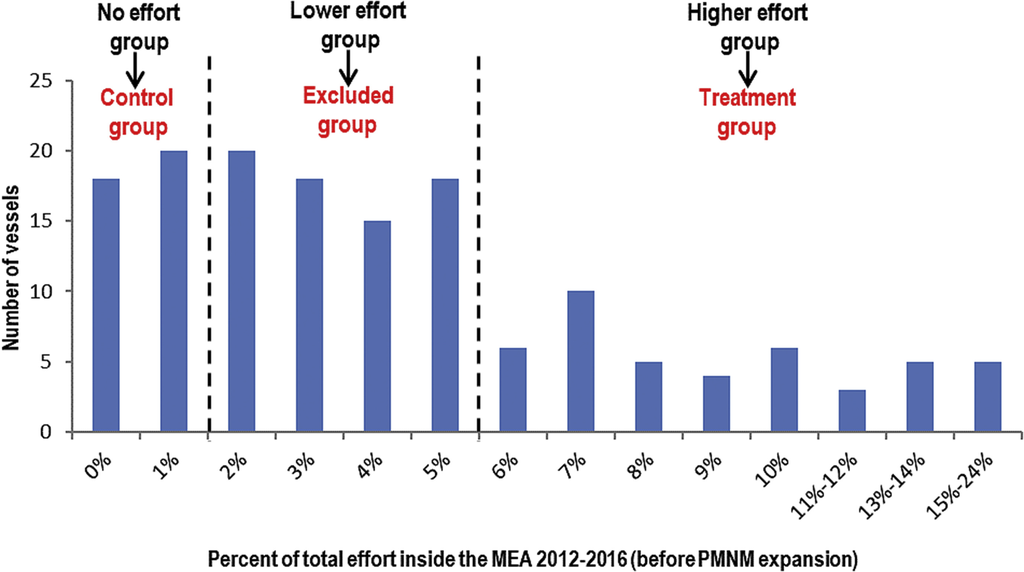

Figure 4 in Chan (2020).

One possible explanation is that having an observer on board causes a vessel to avoid fishing in the Northwestern Hawaiian islands (and maybe the US EEZ in general?). We should check this using obeserver data and logbook summary reports of shallow-set trips. See if we can replicate this figure:

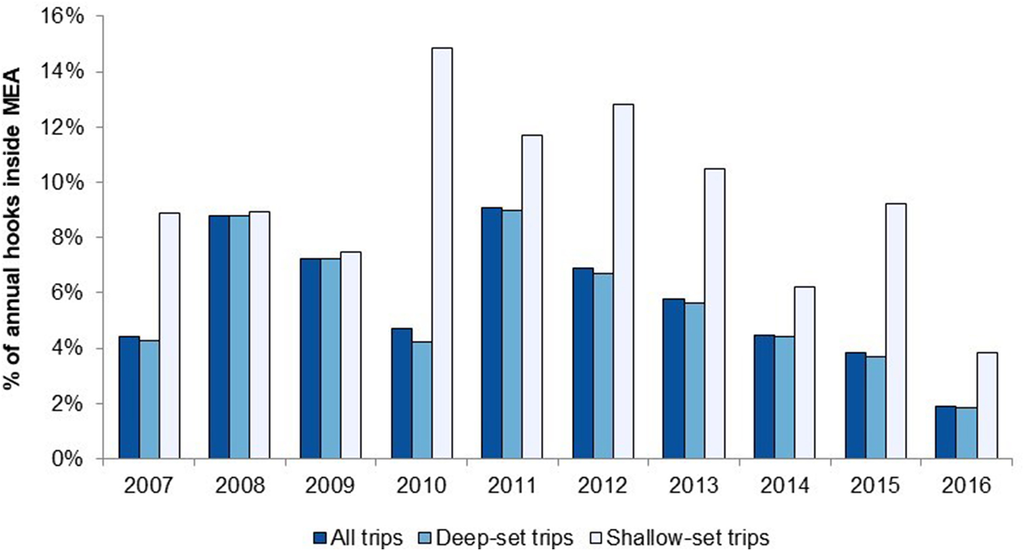

Figure 2 in Chan (2020).

### Robustness check using Jen’s code

```r
################################################################################

# Purpose: determine whether a point location is in/out of PMNM
# Author: Jen Raynor
# Last modified: 3/6/2020
# Inputs:
#   1) GIS files for original and expanded monument boundaries
#   2) Point locations (lat/lon)
# Outputs:
#   1) Dataframe with point identifier, lat, lon, and designation for in/out
# To do:
#   1) Check that we are using the correct projection for overlays
#      Currently using Albers Equal Area centered around Hawaii broadly
#   2) Make sure none of the sets are in the original PMNM bounds as expected
#      Code is provided  in line 101 below to test this.

################################################################################

# ------------------------------------------------------------------------------
# initialize workspace
# ------------------------------------------------------------------------------

library(rgdal) # to read in PMNM shapefiles
library(sp) # to create and manipulate spatial objects
library(raster) # to intersect old/new PMNM bounds to get monument expanded area
#setwd(paste0("C:/Users/jlraynor/Google Drive/Large MPA Data Depository/",         "Replicating Marine Policy Study/JR replication"))

#rm(list = ls())

# ------------------------------------------------------------------------------
# set parameters
# ------------------------------------------------------------------------------

# initialize standard projection for Observer data
obs.proj <- "+proj=longlat +datum=NAD83 +ellps=GRS80"

# set desired projection for all shapefiles - albers equal area
# we should check that this is the best projection for what we are doing
aea.proj <- paste("+proj=aea +lat_1=-8.75 +lat_2=23.75 +lat_0=7.5 +lon_0=-150",
                  "+x_0=0 +y_0=0 +ellps=WGS84 +datum=WGS84 +units=km +no_defs")

# ------------------------------------------------------------------------------
# prepare fishing locations
# ------------------------------------------------------------------------------

# initialize number of simulated fishing locations generated
#n_sets.v <- 1000

# create dataframe of fishing locations
# set_id is mixed character/numeric because I think that's how the real data is
# NOAA.raw <- data.frame(set_id = paste0("A", seq(1, n_sets.v)), set_begin_lat = runif(n_sets.v, 16, 42), set_begin_lon = runif(n_sets.v, -180, -120))

# convert fishing locations to spatialPointsDataFrame
NOAA.sp <- subset(NOAA.raw, !(is.na(set_begin_lon) | is.na(set_begin_lat) ))
coordinates(NOAA.sp) <- ~set_begin_lon + set_begin_lat

# define source projection
proj4string(NOAA.sp) <- CRS(obs.proj)

# reproject to desired projection
NOAA.sp <- spTransform(NOAA.sp, CRS(aea.proj))

# ------------------------------------------------------------------------------
# prepare monument boundaries
# ------------------------------------------------------------------------------

# read in original boundaries shapefile - pre 2016
pmnm_orig.sp <- readOGR(dsn = "PMNM original GIS",
                   layer = "hi_noaa_nwhi_papahanaumokuakea_2006")
# reproject to desired projection
pmnm_orig.sp <- spTransform(pmnm_orig.sp, CRS(aea.proj))

# read in new area boundaries shapefile - post 2016
pmnm_new.sp <- readOGR(dsn = "PMNM expanded GIS/PMNM_py_Albers_files",
                   layer = "PMNM_py_Albers")
```

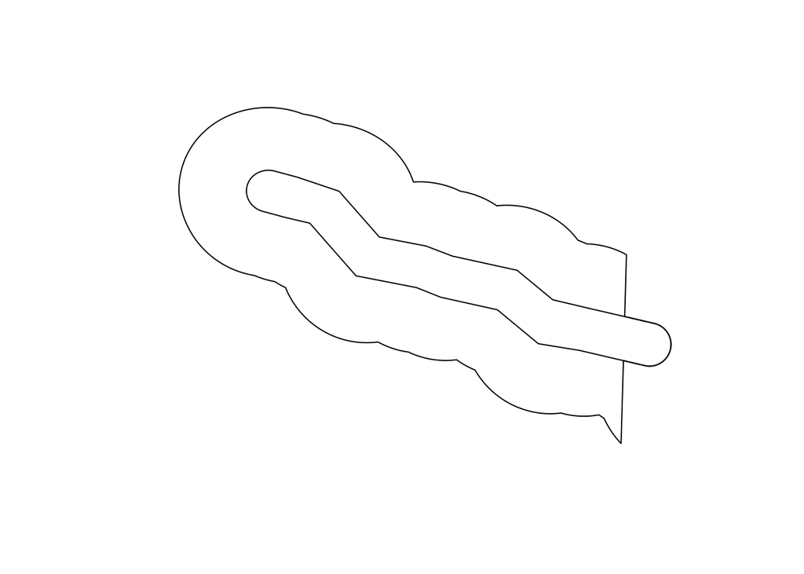

```r
# reproject to desired projection
pmnm_new.sp <- spTransform(pmnm_new.sp, CRS(aea.proj))

# plot to make sure it looks OK
plot(pmnm_new.sp)
plot(pmnm_orig.sp, add = T)
```

```r
# ------------------------------------------------------------------------------
# determine which fishing locations are in the monument
# ------------------------------------------------------------------------------

# create variable for in v. out of original PMNM
# use "TRUE" for inside and "FALSE" for outside
NOAA.sp@data$inside_pmnm_orig <- !is.na(over(NOAA.sp, as(pmnm_orig.sp, "SpatialPolygons")))

# it should be true that none of the sets are in the original pmnm boundary
# if so, this simplifies things; if not, let me know and I can fix the code
# check by summing this variable; should be zero if no sets are inside bounds
sum(NOAA.sp@data$inside_pmnm_orig) == 0
```

```
## [1] FALSE
```

```r
# create variable for in v. out of new PMNM
# use "TRUE" for inside and "FALSE" for outside
NOAA.sp@data$inside_pmnm_new <- !is.na(over(NOAA.sp, as(pmnm_new.sp, "SpatialPolygons")))

# create variable for inside monument expansion area only
# (i.e. in 2016 area but not in 2006 area)
NOAA.sp@data$inside_pmnm_mea <- NOAA.sp@data$inside_pmnm_new - NOAA.sp@data$inside_pmnm_orig

# plot to demonstrate code works
# plot(NOAA.sp, col = as.factor(NOAA.sp@data$inside_pmnm_mea), pch = 20)
# plot(pmnm_new.sp, add = T)
# plot(pmnm_orig.sp, add = T)

### Looks like there were one or two sets inside the original area (right on the boundary). Should probably include these at some point. Re-run with NOAA.subset.

# ------------------------------------------------------------------------------
# save final results
# ------------------------------------------------------------------------------

# save locations and in/out designation as df, if desired
NOAA.df <- NOAA.sp@data
```

Okay, lets run the test. How closely correlated are the two measures of inside/outside?

```r
test.lm <- lm(inside_PMNM ~ inside_pmnm_mea,data=NOAA.df)
summary(test.lm)
```

```
##
## Call:
## lm(formula = inside_PMNM ~ inside_pmnm_mea, data = NOAA.df)
##
## Residuals:
##      Min       1Q   Median       3Q      Max
## -0.00008 -0.00008 -0.00008 -0.00008  0.99992
##
## Coefficients:
##                  Estimate Std. Error  t value Pr(>|t|)
## (Intercept)     8.475e-05  3.114e-05    2.722  0.00649 **
## inside_pmnm_mea 9.999e-01  1.327e-04 7534.677  < 2e-16 ***
## ---
## Signif. codes:  0 '***' 0.001 '**' 0.01 '*' 0.05 '.' 0.1 ' ' 1
##
## Residual standard error: 0.008949 on 87404 degrees of freedom
##   (3441 observations deleted due to missingness)
## Multiple R-squared:  0.9985, Adjusted R-squared:  0.9985
## F-statistic: 5.677e+07 on 1 and 87404 DF,  p-value: < 2.2e-16
```

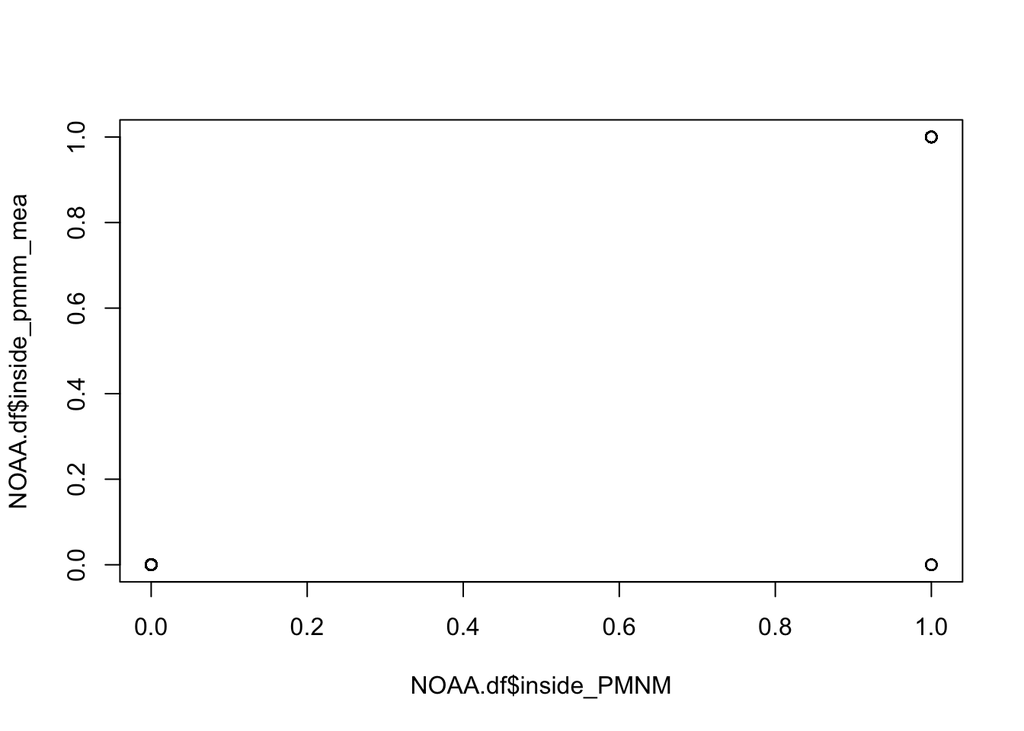

```r
plot(NOAA.df$inside_PMNM,NOAA.df$inside_pmnm_mea)
```

```r
discrep <- subset(NOAA.df, inside_PMNM==1 & inside_pmnm_mea==0) # 7 observations and they are all 2003 or earlier
```

To Do: Replicate Table 3

### Time Series Figures

Average CPUE by month by effort group, 2012–2017.

Defining CPUE. This is going to be an important difference that I don’t see a way to resolve. Chan (2020) defines catch as ALL fish KEPT (mahi-mahi, marlin, etc.). The version of the observer dataset that I have only has data on bigeye, yellowfin, albacore, skipjack, bluefin, unidentified tuna, and swordfish. Let’s combine all of those and divide them by 1,000 hooks to get a “comparable” measure of CPUE. The majority of these species are kept.

```r
NOAA.subset$all.fish <- NOAA.subset$count_bigeye_tuna + NOAA.subset$count_yellowfin_tuna + NOAA.subset$count_albacore_tuna + NOAA.subset$count_skipjack_tuna + NOAA.subset$count_bluefin_tuna + NOAA.subset$count_unid_tuna + NOAA.subset$count_swordfish
NOAA.subset$all.fish.cpue <- (NOAA.subset$all.fish/NOAA.subset$num_hks_set)*1000
```

Now collapse the data at the monthly and treatment group level

There’s a “mistake” here becuase we’re getting data for vessels who are not in either of the three groups: Not really. There are some vessels that show up post 2016 expansion that don’t have any data for 2012-2016. So they’re not in either of the three groups.

```r
monthly.cpue <- aggregate(all.fish.cpue ~ SET_YEAR + SET_MONTH + high_effort + medium_effort + no_effort, NOAA.subset, mean)
monthly.cpue$date <- as.Date(paste(15,monthly.cpue$SET_MONTH,monthly.cpue$SET_YEAR),"%d%m%Y")
```

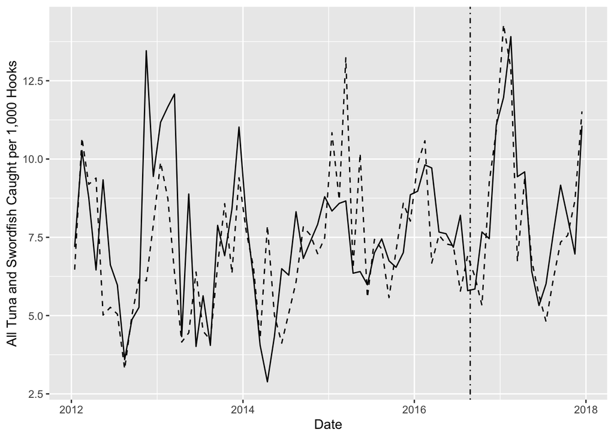

```r
ggplot(data=monthly.cpue, aes(x=date, y=all.fish.cpue)) +
  geom_line(data=subset(monthly.cpue,high_effort==1)) +
  geom_line(data=subset(monthly.cpue,no_effort==1), linetype = "dashed") +
  geom_vline(xintercept = as.numeric(as.Date("2016-08-26")), linetype=4) + labs(x = "Date",y="All Tuna and Swordfish Caught per 1,000 Hooks")
```

This compares “sort-of” favorably with Figure 5 in Chan (2020):

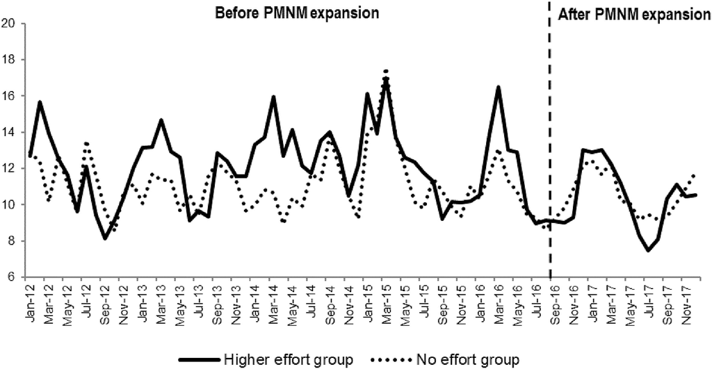

Figure 5 in Chan (2020).

Now we need to generate revenue. Unfortunately, I don’t have access to any fine-scale data on prices. WESPAC publishes information on annual prices in their SAFE Pelagic reports (typically Tables 19(22) and 24). I could try to use that? Monthly price data used to be reported by WPacFIN but they seem to have taken it down.

For 2012 yellowfin tuna, I imputed the price to be $3.27 insteead of the reported price of $1.78, which seems way to low compared to other species that year (and doesn’t add up)

And for 2014 bluefin, I impute the weight per fish to be the average of all other years (since this data is missing): 275.8 lbs

```r
species.prices <- read.csv(file="/Volumes/GoogleDrive/My Drive/Large MPA Data Depository/Prices/annual_species_prices.csv", header=TRUE, sep=",")
combine.with.prices <-merge(NOAA.subset,species.prices,by="SET_YEAR",all.x = TRUE)
NOAA.subset <- combine.with.prices
```

Generate revenue per set (NOTE: For unidentified tuna, I am using yellowfin weight and price. It shouldn’t matter that much but we should decide on the right thing to do here. There is data on price of “other tunas” but no info on weight per fish):

```r
NOAA.subset$all.revenue <- (NOAA.subset$count_bigeye_tuna*NOAA.subset$bigeye_weight*NOAA.subset$bigeye_price) + (NOAA.subset$count_yellowfin_tuna*NOAA.subset$yellowfin_weight*NOAA.subset$yellowfin_price) +
  NOAA.subset$count_albacore_tuna*NOAA.subset$bigeye_weight*NOAA.subset$bigeye_price +
  NOAA.subset$count_skipjack_tuna*NOAA.subset$skipjack_weight*NOAA.subset$skipjack_price +
  NOAA.subset$count_bluefin_tuna*NOAA.subset$bluefin_weight*NOAA.subset$bluefin_price +
  NOAA.subset$count_unid_tuna*NOAA.subset$yellowfin_weight*NOAA.subset$yellowfin_price +
  NOAA.subset$count_swordfish*NOAA.subset$swordfish_weight*NOAA.subset$swordfish_price
```

Now collapse the data by trip (using the last set of the trip as the date of the trip):

```r
library(lubridate)
last.trip.date <- aggregate(date_value ~ trip_id, NOAA.subset, max)
trip.revenue <- aggregate(all.revenue ~ trip_id + high_effort + medium_effort + no_effort, data = NOAA.subset,sum)
trip.cpue <- aggregate(all.fish.cpue ~ trip_id, data = NOAA.subset,mean)
trip.revenue.date <-merge(trip.revenue,last.trip.date,by="trip_id",all.x = TRUE)

trip.revenue.date <-merge(trip.revenue.date,trip.cpue,by="trip_id",all.x = TRUE)

trip.revenue.date$month <- month(trip.revenue.date$date_value)
trip.revenue.date$year <- year(trip.revenue.date$date_value)
setnames(trip.revenue.date, "date_value", "last_date")
```

```r
monthly.revenue.trip <- aggregate(all.revenue ~ year + month + high_effort + medium_effort + no_effort, trip.revenue.date, mean)
monthly.revenue.trip$date <- as.Date(paste(15,monthly.revenue.trip$month,monthly.revenue.trip$year),"%d%m%Y")
```

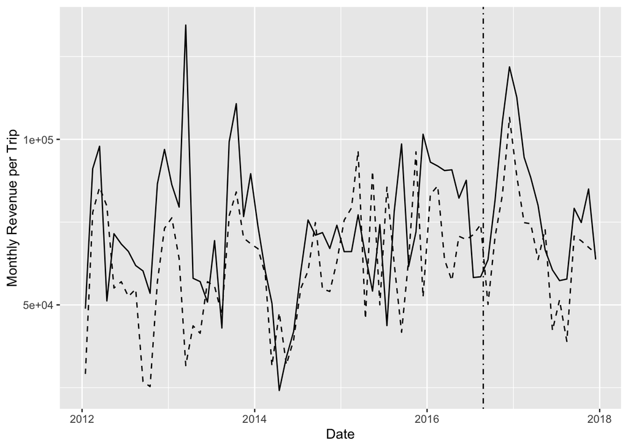

```r
ggplot(data=monthly.revenue.trip, aes(x=date, y=all.revenue)) +
  geom_line(data=subset(monthly.revenue.trip,high_effort==1)) +
  geom_line(data=subset(monthly.revenue.trip,no_effort==1), linetype = "dashed") +
  geom_vline(xintercept = as.numeric(as.Date("2016-08-26")), linetype=4) + labs(x = "Date",y="Monthly Revenue per Trip")
```

Which appears similar to the following:

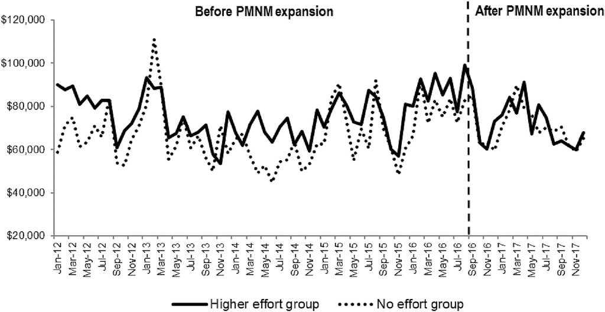

Figure 6 in Chan (2020).

Next step is the inflation of the dataset x20.

“There are 3939 trips recorded in the logbook during the study period for higher and no effort groups. Because the models are using a daily index; effort, catch, and revenue for a trip are distributed evenly across the days of a trip to convert them into daily variables. This process increases the number of observations to 92,977 trip days.”

So a big issue is how to define “where” fishing day took place when there is no data for that date. Michel says she uses the next closest day’s location.

What I’m going to do for now is to collapse the data at the trip level (sum of hooks, catch, and revenue) and record the start and end date.

```r
first.trip.date <- aggregate(date_value ~ trip_id, NOAA.subset, min)
setnames(first.trip.date, "date_value", "first_date")

trip.location <- aggregate(cbind(set_begin_lat,set_begin_lon) ~ trip_id, data = NOAA.subset, mean)

# Need number of days for the trip

trip.revenue.date <-merge(trip.revenue.date,first.trip.date,by="trip_id",all.x = TRUE)
trip.revenue.date <-merge(trip.revenue.date,trip.location,by="trip_id",all.x = TRUE)

trip.revenue.date$trip_days <- trip.revenue.date$last_date - trip.revenue.date$first_date
```

Then spread it across all the days of a trip (at some point we should add three days travel time before the first set and three days travel time after the last set in order to have the number of trip days match the NOAA dataset):

```r
library(tidyr)
library(dplyr)
library(tidyverse)
trip_date_range <- seq(min(as.Date(trip.revenue.date$first_date)), max(as.Date(trip.revenue.date$last_date)), by = 'days')
trip_dat_expanded <- expand.grid(trip_date_range, trip.revenue.date$trip_id)
colnames(trip_dat_expanded) <- c("date", "trip_id")
trip.result <- merge(trip.revenue.date, trip_dat_expanded, by="trip_id", all.y = T)
final.trip.result <- subset(trip.result, trip.result$date>=trip.result$first_date & trip.result$date<=trip.result$last_date)


# trip.revenue.test <- complete(trip.revenue.date, trip_id, date)
#
# trip.revenue.test.two <- merge(trip.revenue.test,trip.revenue.date, by="trip_id",all.x = TRUE)
#
# trip.revenue.test.three <- subset(trip.revenue.test.two, first_date.x>=first_date.y & first_date.x<=last_date.y)
#
# # Doesn't quite work...
#
# trip.revenue.test %>%
#   mutate(Date = as.Date(first_date)) %>%
#   complete(Date = seq.Date(first_date, last_date, by="day"))
```

Let’s generate control variables to run regressions:

```r
final.trip.result$revenue_day <- final.trip.result$all.revenue/as.numeric(final.trip.result$trip_days)

final.trip.result$PMNM_dummy <- as.numeric(final.trip.result$date > "2016-08-24") # Note the Chan (2020) uses August 24th and I used August 26th in my analysis

final.trip.result$high_post <- final.trip.result$PMNM_dummy*final.trip.result$high_effort

trip_vessel <- subset(NOAA.raw, select = c("trip_id","vessel_id","sword"))

trip_vessel <- trip_vessel[!duplicated(trip_vessel$trip_id),]

final.trip.vessel <- merge(trip_vessel,final.trip.result, by = "trip_id", all.y=TRUE)

final.trip.vessel$deep_set <- ifelse(final.trip.vessel$sword==0,1,0)
```

“The entire fishing ground was divided between two fishing convention areas at 150°W with the east of 150°W dividing into northeast (NE) and southeast (SE) at 20°N. The west of 150°W was divided into northwest (NW), central west (CW), and southwest (SW); with latitude at 26°N dividing NW and CW and latitude at 20°N dividing CW and SW.”

150°W is -150

20°N is +20

I could try and match this a little bit better:

" C1it and C2it take the value of one when bigeye tuna closures were in effect that impacted vessel i in period t (based on vessel’s dual permit status and size), and 0 otherwise. There was no closure of the shallow-set fishery between 2012 and 2017. - C1it represents bigeye closure in WCPO - C2it represents bigeye closure in EPO."

I also need to back out a proxy for dual permit vessels. It’s very significant in Chan (2020) revenue regressions. Also need to calculate a density measure but this has a strange positive coefficient in Chan (2020).

```r
final.trip.vessel$NE <- ifelse(final.trip.vessel$set_begin_lon> -150 & final.trip.vessel$set_begin_lat>20,1,0)
final.trip.vessel$SE <- ifelse(final.trip.vessel$set_begin_lon> -150 & final.trip.vessel$set_begin_lat<=20,1,0)

final.trip.vessel$NW <- ifelse(final.trip.vessel$set_begin_lon<= -150 & final.trip.vessel$set_begin_lat>26,1,0)
final.trip.vessel$CW <- ifelse(final.trip.vessel$set_begin_lon<= -150 & final.trip.vessel$set_begin_lat<=26 & final.trip.vessel$set_begin_lat>20,1,0)
final.trip.vessel$SW <- ifelse(final.trip.vessel$set_begin_lon<= -150 & final.trip.vessel$set_begin_lat<=20,1,0)

# Need WCPO closure indicator variable - This code could be improved to calculate based on the date


closures <- subset(NOAA.raw, select = c("date_value","WCPFC_close","IATTC_close"))
closures <- closures[!duplicated(closures$date_value),]
setnames(closures, "date_value", "date")

final.trip.vessel <- merge(closures,final.trip.vessel, by = "date", all.y=TRUE)
```

NOTE: I think I need to fix the months thing

```r
one.lm <- lm(revenue_day ~ high_effort, data = subset(final.trip.vessel, medium_effort==0 & trip_days>0))
summary(one.lm)
```

```
##
## Call:
## lm(formula = revenue_day ~ high_effort, data = subset(final.trip.vessel,
##     medium_effort == 0 & trip_days > 0))
##
## Residuals:
##     Min      1Q  Median      3Q     Max
## -4463.3 -1711.0  -383.5  1295.3 20319.1
##
## Coefficients:
##             Estimate Std. Error t value Pr(>|t|)
## (Intercept)  4463.32      30.92 144.328  < 2e-16 ***
## high_effort   168.65      41.20   4.093 4.28e-05 ***
## ---
## Signif. codes:  0 '***' 0.001 '**' 0.01 '*' 0.05 '.' 0.1 ' ' 1
##
## Residual standard error: 2491 on 14855 degrees of freedom
## Multiple R-squared:  0.001127,   Adjusted R-squared:  0.001059
## F-statistic: 16.76 on 1 and 14855 DF,  p-value: 4.275e-05
```

```r
simpleDID.lm <- lm(revenue_day ~ PMNM_dummy + high_post + high_effort, data = subset(final.trip.vessel, medium_effort==0 & trip_days>0))
summary(simpleDID.lm) # This got really significant all of a sudden... does the randomization matter a lot? It seems to.
```

```
##
## Call:
## lm(formula = revenue_day ~ PMNM_dummy + high_post + high_effort,
##     data = subset(final.trip.vessel, medium_effort == 0 & trip_days >
##         0))
##
## Residuals:
##     Min      1Q  Median      3Q     Max
## -4348.3 -1713.8  -431.5  1241.2 20512.7
##
## Coefficients:
##             Estimate Std. Error t value Pr(>|t|)
## (Intercept)  4305.52      34.33 125.424  < 2e-16 ***
## PMNM_dummy    774.91      76.07  10.187  < 2e-16 ***
## high_post     102.03     100.07   1.020  0.30793
## high_effort   132.83      45.95   2.891  0.00385 **
## ---
## Signif. codes:  0 '***' 0.001 '**' 0.01 '*' 0.05 '.' 0.1 ' ' 1
##
## Residual standard error: 2467 on 14853 degrees of freedom
## Multiple R-squared:  0.01998,    Adjusted R-squared:  0.01978
## F-statistic: 100.9 on 3 and 14853 DF,  p-value: < 2.2e-16
```

```r
full.lm <- lm(revenue_day ~ PMNM_dummy + high_post + factor(vessel_id) + factor(year) + factor(month)*NE + factor(month)*SE + factor(month)*NW + factor(month)*CW + factor(month)*SW + deep_set*NE + deep_set*SE + deep_set*NW + deep_set*CW + deep_set*SW + factor(month)*deep_set + WCPFC_close + IATTC_close + trip_days, data = subset(final.trip.vessel, medium_effort==0 & trip_days>0))
summary(full.lm)
```

```
##
## Call:
## lm(formula = revenue_day ~ PMNM_dummy + high_post + factor(vessel_id) +
##     factor(year) + factor(month) * NE + factor(month) * SE +
##     factor(month) * NW + factor(month) * CW + factor(month) *
##     SW + deep_set * NE + deep_set * SE + deep_set * NW + deep_set *
##     CW + deep_set * SW + factor(month) * deep_set + WCPFC_close +
##     IATTC_close + trip_days, data = subset(final.trip.vessel,
##     medium_effort == 0 & trip_days > 0))
##
## Residuals:
##     Min      1Q  Median      3Q     Max
## -5764.2 -1134.7   -77.8   900.2 16727.2
##
## Coefficients: (27 not defined because of singularities)
##                            Estimate Std. Error t value Pr(>|t|)
## (Intercept)               13500.712    676.143  19.967  < 2e-16 ***
## PMNM_dummy                 -170.750    101.179  -1.688 0.091508 .
## high_post                   -84.642     77.911  -1.086 0.277322
## factor(vessel_id)FV112251  1518.051    233.984   6.488 8.99e-11 ***
## factor(vessel_id)FV115403  -384.966    207.996  -1.851 0.064213 .
## factor(vessel_id)FV131192   905.196    185.640   4.876 1.09e-06 ***
## factor(vessel_id)FV145470  3661.549    177.319  20.649  < 2e-16 ***
## factor(vessel_id)FV151608   586.969    193.575   3.032 0.002431 **
## factor(vessel_id)FV154479  2042.166    204.139  10.004  < 2e-16 ***
## factor(vessel_id)FV166107   264.721    191.558   1.382 0.167010
## factor(vessel_id)FV168978  1270.029    185.275   6.855 7.42e-12 ***
## factor(vessel_id)FV181393  -695.818    188.981  -3.682 0.000232 ***
## factor(vessel_id)FV186234  1705.588    206.242   8.270  < 2e-16 ***
## factor(vessel_id)FV196518   464.616    187.048   2.484 0.013005 *
## factor(vessel_id)FV229518  1350.865    179.165   7.540 4.98e-14 ***
## factor(vessel_id)FV230689   359.053    243.901   1.472 0.141009
## factor(vessel_id)FV238663  -696.016    231.057  -3.012 0.002597 **
## factor(vessel_id)FV240366  2279.601    208.192  10.950  < 2e-16 ***
## factor(vessel_id)FV243584  1423.658    175.900   8.094 6.25e-16 ***
## factor(vessel_id)FV261850  1621.430    184.190   8.803  < 2e-16 ***
## factor(vessel_id)FV266227  2598.164    203.354  12.777  < 2e-16 ***
## factor(vessel_id)FV280095  -148.297    170.151  -0.872 0.383464
## factor(vessel_id)FV302925  1070.208    181.349   5.901 3.68e-09 ***
## factor(vessel_id)FV308968  3327.951    168.533  19.747  < 2e-16 ***
```

[output cut: 145 more lines]

```
## factor(month)4:deep_set   -2699.855    672.817  -4.013 6.03e-05 ***
## factor(month)5:deep_set    2263.589    610.095   3.710 0.000208 ***
## factor(month)6:deep_set    2783.367    615.869   4.519 6.25e-06 ***
## factor(month)7:deep_set          NA         NA      NA       NA
## factor(month)8:deep_set    2333.506    688.035   3.392 0.000697 ***
## factor(month)9:deep_set          NA         NA      NA       NA
## factor(month)10:deep_set         NA         NA      NA       NA
## factor(month)11:deep_set   5208.269    548.005   9.504  < 2e-16 ***
## factor(month)12:deep_set   2943.067    601.464   4.893 1.00e-06 ***
## ---
## Signif. codes:  0 '***' 0.001 '**' 0.01 '*' 0.05 '.' 0.1 ' ' 1
##
## Residual standard error: 1785 on 14706 degrees of freedom
## Multiple R-squared:  0.4922, Adjusted R-squared:  0.487
## F-statistic: 95.01 on 150 and 14706 DF,  p-value: < 2.2e-16
```

```r
coeftest(full.lm, vcov = vcovHC(full.lm, type="HC1"))
```

```
##
## t test of coefficients:
##
##                             Estimate Std. Error  t value  Pr(>|t|)
## (Intercept)               13500.7116   552.0714  24.4546 < 2.2e-16 ***
## PMNM_dummy                 -170.7502    95.8671  -1.7811 0.0749146 .
## high_post                   -84.6417    78.3699  -1.0800 0.2801474
## factor(vessel_id)FV112251  1518.0512   152.0470   9.9841 < 2.2e-16 ***
## factor(vessel_id)FV115403  -384.9663   179.3955  -2.1459 0.0318966 *
## factor(vessel_id)FV131192   905.1959   113.6174   7.9671 1.744e-15 ***
## factor(vessel_id)FV145470  3661.5487   195.5824  18.7213 < 2.2e-16 ***
## factor(vessel_id)FV151608   586.9692   176.4358   3.3268 0.0008806 ***
## factor(vessel_id)FV154479  2042.1656   166.9855  12.2296 < 2.2e-16 ***
## factor(vessel_id)FV166107   264.7215   144.3013   1.8345 0.0665993 .
## factor(vessel_id)FV168978  1270.0286   155.6981   8.1570 3.711e-16 ***
## factor(vessel_id)FV181393  -695.8184   142.6696  -4.8771 1.088e-06 ***
## factor(vessel_id)FV186234  1705.5881   225.1360   7.5758 3.781e-14 ***
## factor(vessel_id)FV196518   464.6164   153.4058   3.0287 0.0024605 **
## factor(vessel_id)FV229518  1350.8647   143.0812   9.4412 < 2.2e-16 ***
## factor(vessel_id)FV230689   359.0529   229.0000   1.5679 0.1169221
## factor(vessel_id)FV238663  -696.0155   201.2400  -3.4586 0.0005445 ***
## factor(vessel_id)FV240366  2279.6006   188.6571  12.0833 < 2.2e-16 ***
## factor(vessel_id)FV243584  1423.6577   146.3287   9.7292 < 2.2e-16 ***
## factor(vessel_id)FV261850  1621.4299   240.5389   6.7408 1.634e-11 ***
## factor(vessel_id)FV266227  2598.1640   248.8577  10.4404 < 2.2e-16 ***
## factor(vessel_id)FV280095  -148.2967   104.0152  -1.4257 0.1539700
## factor(vessel_id)FV302925  1070.2076   152.1332   7.0347 2.085e-12 ***
## factor(vessel_id)FV308968  3327.9510   166.2195  20.0214 < 2.2e-16 ***
## factor(vessel_id)FV317174   263.0139   133.1865   1.9748 0.0483119 *
## factor(vessel_id)FV335081   698.9037   185.6310   3.7650 0.0001672 ***
## factor(vessel_id)FV343361  1089.5478   150.1262   7.2575 4.139e-13 ***
## factor(vessel_id)FV355346  1837.6759   170.9838  10.7477 < 2.2e-16 ***
## factor(vessel_id)FV374928 -1603.2461   189.8951  -8.4428 < 2.2e-16 ***
## factor(vessel_id)FV412074  1948.8207   166.7934  11.6840 < 2.2e-16 ***
## factor(vessel_id)FV435589 -1116.2903   135.1454  -8.2599 < 2.2e-16 ***
## factor(vessel_id)FV448115   369.6283    91.0967   4.0575 4.985e-05 ***
## factor(vessel_id)FV456335  -717.4085   135.3614  -5.2999 1.175e-07 ***
## factor(vessel_id)FV457324   358.3743   136.5298   2.6249 0.0086769 **
## factor(vessel_id)FV487522    11.2098   186.5504   0.0601 0.9520848
## factor(vessel_id)FV499487   -38.2803   114.9287  -0.3331 0.7390797
```

[output cut: 102 more lines]

```
## factor(month)10:CW         1971.0029   211.4235   9.3225 < 2.2e-16 ***
## factor(month)11:CW         1761.1963   194.9455   9.0343 < 2.2e-16 ***
## factor(month)12:CW          899.3513   188.5255   4.7705 1.856e-06 ***
## NE:deep_set                 764.0893   422.9009   1.8068 0.0708168 .
## NW:deep_set                1443.7689   245.5623   5.8794 4.206e-09 ***
## factor(month)2:deep_set    2223.5837   353.7776   6.2853 3.365e-10 ***
## factor(month)3:deep_set    1625.2313   462.7678   3.5120 0.0004461 ***
## factor(month)4:deep_set   -2699.8549   468.4451  -5.7634 8.407e-09 ***
## factor(month)5:deep_set    2263.5894   512.9040   4.4133 1.025e-05 ***
## factor(month)6:deep_set    2783.3671   447.7437   6.2164 5.223e-10 ***
## factor(month)8:deep_set    2333.5064   420.2646   5.5525 2.865e-08 ***
## factor(month)11:deep_set   5208.2692   365.2716  14.2586 < 2.2e-16 ***
## factor(month)12:deep_set   2943.0666   400.1694   7.3546 2.017e-13 ***
## ---
## Signif. codes:  0 '***' 0.001 '**' 0.01 '*' 0.05 '.' 0.1 ' ' 1
```

```r
# Notes: adding vessel FE gives a strong significant result, same with year and month dummies, deep_set makes it a little weaker, area dummies make it stronger, area-month interactions make it weaker, area-gear interactions make it weaker, closure dummies don't seem to change anything (interact with sword dummy?), trip length makes it weaker

# Now it's time to collapse the data and see what happens

trip.level <- aggregate(cbind(revenue_day,PMNM_dummy, high_post, high_effort, trip_days) ~ trip_id + vessel_id,data = subset(final.trip.vessel, medium_effort==0 & trip_days>0),mean)
trip.level$revenue_trip <- trip.level$revenue_day*trip.level$trip_days

controls <- subset(final.trip.vessel, select = c("trip_id","year","month","NE","SE","NW","CW","SW","deep_set","last_date"))
controls <- controls[!duplicated(controls$trip_id),]

trip.level <- merge(controls,trip.level, by = "trip_id", all.y=TRUE)

closures$last_date <- closures$date

trip.level <- merge(closures,trip.level, by = "last_date", all.y=TRUE)

simpleDID.trip.lm <- lm(revenue_trip ~ PMNM_dummy + high_post + high_effort, data = trip.level)
summary(simpleDID.trip.lm) # It's no longer significant (confirmed at least four times)...
```

```
##
## Call:
## lm(formula = revenue_trip ~ PMNM_dummy + high_post + high_effort,
##     data = trip.level)
##
## Residuals:
##    Min     1Q Median     3Q    Max
## -74255 -26868  -3929  20646 227372
##
## Coefficients:
##             Estimate Std. Error t value Pr(>|t|)
## (Intercept)    62670       2066  30.341  < 2e-16 ***
## PMNM_dummy      7316       4504   1.624 0.104618
## high_post       1667       6047   0.276 0.782861
## high_effort     9371       2830   3.312 0.000964 ***
## ---
## Signif. codes:  0 '***' 0.001 '**' 0.01 '*' 0.05 '.' 0.1 ' ' 1
##
## Residual standard error: 37540 on 907 degrees of freedom
## Multiple R-squared:  0.02507,    Adjusted R-squared:  0.02185
## F-statistic: 7.775 on 3 and 907 DF,  p-value: 3.956e-05
```

```r
# The Big Test:

full.trip.lm <- lm(revenue_trip ~ PMNM_dummy + high_post + factor(vessel_id) + factor(year) + factor(month)*NE + factor(month)*SE + factor(month)*NW + factor(month)*CW + factor(month)*SW + deep_set*NE + deep_set*SE + deep_set*NW + deep_set*CW + deep_set*SW + factor(month)*deep_set + WCPFC_close + IATTC_close + trip_days, data = trip.level)
summary(full.trip.lm)
```

```
##
## Call:
## lm(formula = revenue_trip ~ PMNM_dummy + high_post + factor(vessel_id) +
##     factor(year) + factor(month) * NE + factor(month) * SE +
##     factor(month) * NW + factor(month) * CW + factor(month) *
##     SW + deep_set * NE + deep_set * SE + deep_set * NW + deep_set *
##     CW + deep_set * SW + factor(month) * deep_set + WCPFC_close +
##     IATTC_close + trip_days, data = trip.level)
##
## Residuals:
##    Min     1Q Median     3Q    Max
## -66552 -17431  -1934  14065 198560
##
## Coefficients: (27 not defined because of singularities)
##                           Estimate Std. Error t value Pr(>|t|)
## (Intercept)               124143.8    47624.8   2.607 0.009321 **
## PMNM_dummy                 -2673.4     6737.7  -0.397 0.691642
## high_post                   -958.2     4924.8  -0.195 0.845786
## factor(vessel_id)FV112251  37465.7    16306.4   2.298 0.021855 *
## factor(vessel_id)FV115403  13434.6    13280.0   1.012 0.312032
## factor(vessel_id)FV131192  25292.2    12689.1   1.993 0.046595 *
## factor(vessel_id)FV145470  74881.0    12214.9   6.130 1.41e-09 ***
## factor(vessel_id)FV151608  20841.3    12576.3   1.657 0.097892 .
## factor(vessel_id)FV154479  50994.4    14401.6   3.541 0.000423 ***
## factor(vessel_id)FV166107  18943.3    13312.2   1.423 0.155145
## factor(vessel_id)FV168978  24496.2    12821.1   1.911 0.056430 .
## factor(vessel_id)FV181393   4222.2    12420.8   0.340 0.734004
## factor(vessel_id)FV186234  38585.0    13516.3   2.855 0.004425 **
## factor(vessel_id)FV196518  22198.0    12401.0   1.790 0.073850 .
## factor(vessel_id)FV229518  28646.3    12090.6   2.369 0.018070 *
## factor(vessel_id)FV230689  18705.0    16714.1   1.119 0.263445
## factor(vessel_id)FV238663   4584.2    14761.5   0.311 0.756227
## factor(vessel_id)FV240366  53409.9    15214.6   3.510 0.000474 ***
## factor(vessel_id)FV243584  33755.0    12157.1   2.777 0.005629 **
## factor(vessel_id)FV261850  33680.4    12177.9   2.766 0.005818 **
## factor(vessel_id)FV266227  56733.5    13726.6   4.133 3.98e-05 ***
## factor(vessel_id)FV280095   8872.2    11876.8   0.747 0.455285
## factor(vessel_id)FV302925  28641.2    12390.4   2.312 0.021068 *
## factor(vessel_id)FV308968  68170.1    11974.3   5.693 1.78e-08 ***
## factor(vessel_id)FV317174  15957.7    12232.7   1.305 0.192455
```

[output cut: 144 more lines]

```
## factor(month)4:deep_set   -37564.8    46047.7  -0.816 0.414882
## factor(month)5:deep_set    49706.9    43097.5   1.153 0.249126
## factor(month)6:deep_set    55105.2    43414.2   1.269 0.204727
## factor(month)7:deep_set         NA         NA      NA       NA
## factor(month)8:deep_set    35589.6    48661.6   0.731 0.464779
## factor(month)9:deep_set         NA         NA      NA       NA
## factor(month)10:deep_set        NA         NA      NA       NA
## factor(month)11:deep_set   68182.1    37145.4   1.836 0.066815 .
## factor(month)12:deep_set   60838.2    41394.8   1.470 0.142055
## ---
## Signif. codes:  0 '***' 0.001 '**' 0.01 '*' 0.05 '.' 0.1 ' ' 1
##
## Residual standard error: 28340 on 760 degrees of freedom
## Multiple R-squared:  0.5344, Adjusted R-squared:  0.4425
## F-statistic: 5.815 on 150 and 760 DF,  p-value: < 2.2e-16
```

Now let’s do the same thing for CPUE. We get a statisically significant negative coefficient.

```r
full.cpue.lm <- lm(all.fish.cpue ~ PMNM_dummy + high_post + factor(vessel_id) + factor(year) + factor(month)*NE + factor(month)*SE + factor(month)*NW + factor(month)*CW + factor(month)*SW + deep_set*NE + deep_set*SE + deep_set*NW + deep_set*CW + deep_set*SW + factor(month)*deep_set + WCPFC_close + IATTC_close + trip_days, data = subset(final.trip.vessel, medium_effort==0 & trip_days>0))
summary(full.cpue.lm)
```

```
##
## Call:
## lm(formula = all.fish.cpue ~ PMNM_dummy + high_post + factor(vessel_id) +
##     factor(year) + factor(month) * NE + factor(month) * SE +
##     factor(month) * NW + factor(month) * CW + factor(month) *
##     SW + deep_set * NE + deep_set * SE + deep_set * NW + deep_set *
##     CW + deep_set * SW + factor(month) * deep_set + WCPFC_close +
##     IATTC_close + trip_days, data = subset(final.trip.vessel,
##     medium_effort == 0 & trip_days > 0))
##
## Residuals:
##     Min      1Q  Median      3Q     Max
## -8.9493 -1.7596 -0.2444  1.4013 27.8886
##
## Coefficients: (27 not defined because of singularities)
##                            Estimate Std. Error t value Pr(>|t|)
## (Intercept)               20.958948   1.083684  19.340  < 2e-16 ***
## PMNM_dummy                -0.152704   0.162164  -0.942 0.346379
## high_post                 -0.277639   0.124871  -2.223 0.026203 *
## factor(vessel_id)FV112251 -0.486588   0.375016  -1.298 0.194475
## factor(vessel_id)FV115403 -1.918313   0.333364  -5.754 8.87e-09 ***
## factor(vessel_id)FV131192 -1.193269   0.297534  -4.011 6.09e-05 ***
## factor(vessel_id)FV145470  0.402816   0.284197   1.417 0.156392
## factor(vessel_id)FV151608 -2.079080   0.310250  -6.701 2.14e-11 ***
## factor(vessel_id)FV154479 -0.045046   0.327182  -0.138 0.890496
## factor(vessel_id)FV166107 -2.660079   0.307018  -8.664  < 2e-16 ***
## factor(vessel_id)FV168978  0.428043   0.296947   1.441 0.149472
## factor(vessel_id)FV181393 -3.976430   0.302889 -13.128  < 2e-16 ***
## factor(vessel_id)FV186234 -2.205279   0.330553  -6.671 2.62e-11 ***
## factor(vessel_id)FV196518 -1.759264   0.299789  -5.868 4.50e-09 ***
## factor(vessel_id)FV229518 -0.341063   0.287156  -1.188 0.234960
## factor(vessel_id)FV230689 -1.244741   0.390911  -3.184 0.001455 **
## factor(vessel_id)FV238663 -2.536253   0.370325  -6.849 7.75e-12 ***
## factor(vessel_id)FV240366  0.282621   0.333678   0.847 0.397016
## factor(vessel_id)FV243584 -0.129225   0.281923  -0.458 0.646693
## factor(vessel_id)FV261850 -0.276274   0.295209  -0.936 0.349361
## factor(vessel_id)FV266227 -0.719239   0.325924  -2.207 0.027346 *
## factor(vessel_id)FV280095 -2.486026   0.272709  -9.116  < 2e-16 ***
## factor(vessel_id)FV302925 -1.315334   0.290657  -4.525 6.08e-06 ***
## factor(vessel_id)FV308968 -0.848054   0.270115  -3.140 0.001695 **
```

[output cut: 145 more lines]

```
## factor(month)4:deep_set   -5.935747   1.078353  -5.504 3.77e-08 ***
## factor(month)5:deep_set    3.169515   0.977825   3.241 0.001192 **
## factor(month)6:deep_set    3.679691   0.987080   3.728 0.000194 ***
## factor(month)7:deep_set          NA         NA      NA       NA
## factor(month)8:deep_set    0.955529   1.102743   0.867 0.386229
## factor(month)9:deep_set          NA         NA      NA       NA
## factor(month)10:deep_set         NA         NA      NA       NA
## factor(month)11:deep_set   3.154068   0.878312   3.591 0.000330 ***
## factor(month)12:deep_set   1.056919   0.963993   1.096 0.272923
## ---
## Signif. codes:  0 '***' 0.001 '**' 0.01 '*' 0.05 '.' 0.1 ' ' 1
##
## Residual standard error: 2.861 on 14706 degrees of freedom
## Multiple R-squared:  0.5075, Adjusted R-squared:  0.5025
## F-statistic:   101 on 150 and 14706 DF,  p-value: < 2.2e-16
```

What happens if we use data from days when fishing actually occurred and drop the invented observations:

NOTE: need to check why sample size of real.cpue increases so much

NOTE: what if we use the smoothed date but from actual fishing days?

```r
#just.days <- subset(trip.revenue.date,select = c("trip_id","trip_days"),)

#real.cpue <-merge(NOAA.subset,just.days,by="trip_id",all.x = TRUE)

#real.cpue$high_post <- real.cpue$PMNM_dummy*real.cpue$high_effort

just.cpue <- subset(NOAA.subset,select = c("trip_id","date_value","all.fish.cpue"))

setnames(just.cpue, "date_value", "date")

real.cpue <-merge(final.trip.vessel,just.cpue,by=c("trip_id","date"),all.x = TRUE)

real.cpue.lm <- lm(all.fish.cpue.y ~ PMNM_dummy + high_post + factor(vessel_id) + factor(year) + factor(month)*NE + factor(month)*SE + factor(month)*NW + factor(month)*CW + factor(month)*SW + deep_set*NE + deep_set*SE + deep_set*NW + deep_set*CW + deep_set*SW + factor(month)*deep_set + WCPFC_close + IATTC_close + trip_days, data = subset(real.cpue, medium_effort==0 & trip_days>0))
summary(real.cpue.lm)
```

```
##
## Call:
## lm(formula = all.fish.cpue.y ~ PMNM_dummy + high_post + factor(vessel_id) +
##     factor(year) + factor(month) * NE + factor(month) * SE +
##     factor(month) * NW + factor(month) * CW + factor(month) *
##     SW + deep_set * NE + deep_set * SE + deep_set * NW + deep_set *
##     CW + deep_set * SW + factor(month) * deep_set + WCPFC_close +
##     IATTC_close + trip_days, data = subset(real.cpue, medium_effort ==
##     0 & trip_days > 0))
##
## Residuals:
##     Min      1Q  Median      3Q     Max
## -15.202  -3.329  -1.053   1.884 101.242
##
## Coefficients: (27 not defined because of singularities)
##                           Estimate Std. Error t value Pr(>|t|)
## (Intercept)               20.59668    2.39378   8.604  < 2e-16 ***
## PMNM_dummy                -0.07116    0.35817  -0.199 0.842522
## high_post                 -0.22580    0.27367  -0.825 0.409355
## factor(vessel_id)FV112251 -0.52197    0.83262  -0.627 0.530734
## factor(vessel_id)FV115403 -2.02937    0.77400  -2.622 0.008754 **
## factor(vessel_id)FV131192 -1.33845    0.68769  -1.946 0.051640 .
## factor(vessel_id)FV145470  0.31715    0.65326   0.485 0.627343
## factor(vessel_id)FV151608 -2.03792    0.72288  -2.819 0.004822 **
## factor(vessel_id)FV154479 -0.17161    0.74808  -0.229 0.818558
## factor(vessel_id)FV166107 -2.78933    0.69974  -3.986 6.75e-05 ***
## factor(vessel_id)FV168978  0.39154    0.70284   0.557 0.577485
## factor(vessel_id)FV181393 -4.08275    0.71833  -5.684 1.35e-08 ***
## factor(vessel_id)FV186234 -2.38758    0.74760  -3.194 0.001408 **
## factor(vessel_id)FV196518 -1.99724    0.68087  -2.933 0.003359 **
## factor(vessel_id)FV229518 -0.45322    0.66165  -0.685 0.493369
## factor(vessel_id)FV230689 -1.10673    0.89354  -1.239 0.215522
## factor(vessel_id)FV238663 -2.48447    0.84804  -2.930 0.003399 **
## factor(vessel_id)FV240366  0.25704    0.76976   0.334 0.738438
## factor(vessel_id)FV243584 -0.14270    0.65471  -0.218 0.827468
## factor(vessel_id)FV261850 -0.31616    0.68944  -0.459 0.646550
## factor(vessel_id)FV266227 -0.91813    0.74316  -1.235 0.216687
## factor(vessel_id)FV280095 -2.68308    0.64141  -4.183 2.90e-05 ***
## factor(vessel_id)FV302925 -1.35207    0.67019  -2.017 0.043672 *
## factor(vessel_id)FV308968 -0.80292    0.62752  -1.280 0.200739
```

[output cut: 146 more lines]

```
## factor(month)5:deep_set    2.87910    2.15339   1.337 0.181245
## factor(month)6:deep_set    3.33174    2.17438   1.532 0.125481
## factor(month)7:deep_set         NA         NA      NA       NA
## factor(month)8:deep_set    0.95062    2.38845   0.398 0.690631
## factor(month)9:deep_set         NA         NA      NA       NA
## factor(month)10:deep_set        NA         NA      NA       NA
## factor(month)11:deep_set   2.75435    1.94171   1.419 0.156064
## factor(month)12:deep_set   0.98385    2.10018   0.468 0.639464
## ---
## Signif. codes:  0 '***' 0.001 '**' 0.01 '*' 0.05 '.' 0.1 ' ' 1
##
## Residual standard error: 5.79 on 12421 degrees of freedom
##   (2313 observations deleted due to missingness)
## Multiple R-squared:  0.2015, Adjusted R-squared:  0.1919
## F-statistic:  20.9 on 150 and 12421 DF,  p-value: < 2.2e-16
```

```r
real.cpue.lm <- lm(all.fish.cpue.x ~ PMNM_dummy + high_post + factor(vessel_id) + factor(year) + factor(month)*NE + factor(month)*SE + factor(month)*NW + factor(month)*CW + factor(month)*SW + deep_set*NE + deep_set*SE + deep_set*NW + deep_set*CW + deep_set*SW + factor(month)*deep_set + WCPFC_close + IATTC_close + trip_days, data = subset(real.cpue, medium_effort==0 & trip_days>0 & all.fish.cpue.y>=0))
summary(real.cpue.lm)
```

```
##
## Call:
## lm(formula = all.fish.cpue.x ~ PMNM_dummy + high_post + factor(vessel_id) +
##     factor(year) + factor(month) * NE + factor(month) * SE +
##     factor(month) * NW + factor(month) * CW + factor(month) *
##     SW + deep_set * NE + deep_set * SE + deep_set * NW + deep_set *
##     CW + deep_set * SW + factor(month) * deep_set + WCPFC_close +
##     IATTC_close + trip_days, data = subset(real.cpue, medium_effort ==
##     0 & trip_days > 0 & all.fish.cpue.y >= 0))
##
## Residuals:
##     Min      1Q  Median      3Q     Max
## -9.6538 -1.7993 -0.2159  1.4146 27.7986
##
## Coefficients: (27 not defined because of singularities)
##                           Estimate Std. Error t value Pr(>|t|)
## (Intercept)               20.63271    1.19506  17.265  < 2e-16 ***
## PMNM_dummy                -0.17903    0.17881  -1.001 0.316754
## high_post                 -0.21023    0.13663  -1.539 0.123904
## factor(vessel_id)FV112251 -0.57871    0.41567  -1.392 0.163881
## factor(vessel_id)FV115403 -2.01937    0.38641  -5.226 1.76e-07 ***
## factor(vessel_id)FV131192 -1.33208    0.34332  -3.880 0.000105 ***
## factor(vessel_id)FV145470  0.33219    0.32613   1.019 0.308422
## factor(vessel_id)FV151608 -2.02268    0.36089  -5.605 2.13e-08 ***
## factor(vessel_id)FV154479 -0.17842    0.37346  -0.478 0.632841
## factor(vessel_id)FV166107 -2.78862    0.34933  -7.983 1.56e-15 ***
## factor(vessel_id)FV168978  0.41718    0.35088   1.189 0.234485
## factor(vessel_id)FV181393 -4.07658    0.35862 -11.368  < 2e-16 ***
## factor(vessel_id)FV186234 -2.37667    0.37323  -6.368 1.98e-10 ***
## factor(vessel_id)FV196518 -1.98075    0.33991  -5.827 5.78e-09 ***
## factor(vessel_id)FV229518 -0.43542    0.33032  -1.318 0.187472
## factor(vessel_id)FV230689 -1.08028    0.44609  -2.422 0.015463 *
## factor(vessel_id)FV238663 -2.47394    0.42337  -5.843 5.24e-09 ***
## factor(vessel_id)FV240366  0.24534    0.38429   0.638 0.523213
## factor(vessel_id)FV243584 -0.14534    0.32685  -0.445 0.656581
## factor(vessel_id)FV261850 -0.32495    0.34419  -0.944 0.345147
## factor(vessel_id)FV266227 -0.92240    0.37101  -2.486 0.012925 *
## factor(vessel_id)FV280095 -2.69681    0.32022  -8.422  < 2e-16 ***
## factor(vessel_id)FV302925 -1.34534    0.33458  -4.021 5.83e-05 ***
## factor(vessel_id)FV308968 -0.79285    0.31328  -2.531 0.011392 *
```

[output cut: 145 more lines]

```
## factor(month)4:deep_set   -6.12717    1.20665  -5.078 3.87e-07 ***
## factor(month)5:deep_set    2.92769    1.07505   2.723 0.006472 **
## factor(month)6:deep_set    3.38932    1.08553   3.122 0.001799 **
## factor(month)7:deep_set         NA         NA      NA       NA
## factor(month)8:deep_set    1.01471    1.19240   0.851 0.394796
## factor(month)9:deep_set         NA         NA      NA       NA
## factor(month)10:deep_set        NA         NA      NA       NA
## factor(month)11:deep_set   2.75842    0.96937   2.846 0.004440 **
## factor(month)12:deep_set   1.08483    1.04848   1.035 0.300843
## ---
## Signif. codes:  0 '***' 0.001 '**' 0.01 '*' 0.05 '.' 0.1 ' ' 1
##
## Residual standard error: 2.891 on 12421 degrees of freedom
## Multiple R-squared:  0.5033, Adjusted R-squared:  0.4973
## F-statistic:  83.9 on 150 and 12421 DF,  p-value: < 2.2e-16
```

```r
# Seems to matter a great deal which one you use
```